# Analisis de ExAC para variantes missense en Rasopatías

## Introducción

se analizarán 14 genes, previamente asociados a rasopatías.

```
##  [1] "PAH"    "RHO"    "PTPN11" "SOS1"   "RASA1"  "NF1"    "HRAS"
##  [8] "KRAS"   "NRAS"   "RAF1"   "MAP2K1" "MAP2K2" "SPRED1" "CBL"
```

Cada uno de estos genes es buscado manualmente en la base de datos Esembl y se extraen sus coordenadas genomicas. A partir de estas coordenadas se realiza un subset en un archivo VCF correspondiente a la base de datos **ExAC**. El archivo resultante es luego anotado con SNPEFF y Clinvar. Se utilza el script *VishnoConverter.py* para convertir el archivo VCF final, a una tabla con los datos de interés y se agrega información estructural (PDB y mapeo de las variantes sobre los cristales) de las proteínas que son codificadas por estos genes.

## Datos preliminares y limpieza de las tablas

Se encuentran mas de 45 mil features de secuencia dentro de las variantes reportadas para ExAC para las regiones evaluadas, de las cuales 2697 corresponden a variantes missense (sólo para los transcriptos canónicos). En estas regiones se encontró un mayor número de genes que los 14 iniciales, por lo que se procede con el filtrado del dataset, de manera de obtener variantes missense que pertenezcan únicamente a estos genes.

Se obtienen entonces **2274** variantes missense para los 14 genes evaluados.

#### Variantes por gen

```
##
##    CBL   HRAS   KRAS MAP2K1 MAP2K2    NF1   NRAS    PAH PTPN11   RAF1
##    246     42     30     49    119    502     30    178    111    152
##  RASA1    RHO   SOS1 SPRED1
##    248    146    302    119
```

#### Variantes por categoría de Clinvar

```
##
##   0   1   2   3   4   5 255
##  65  77  10  10   4  54   2
```

| CLNSIG | Clinical significance |
| --- | --- |
| 0 | unknown |
| 1 | untested |
| 2 | non-pathogenic |
| 3 | probable-non-pathogenic |
| 4 | probable-pathogenic |
| 5 | pathogenic |
| 6 | drug-response |
| 7 | histocompatibility |
| 255 | other |

#### Comparación de frecuencias alelicas de 1K Genome y ExAC

En este paso se realiza la estimación que todas aquellas variantes que no posean una frecuencia alélica en 1KG tienen valor igual a 0.

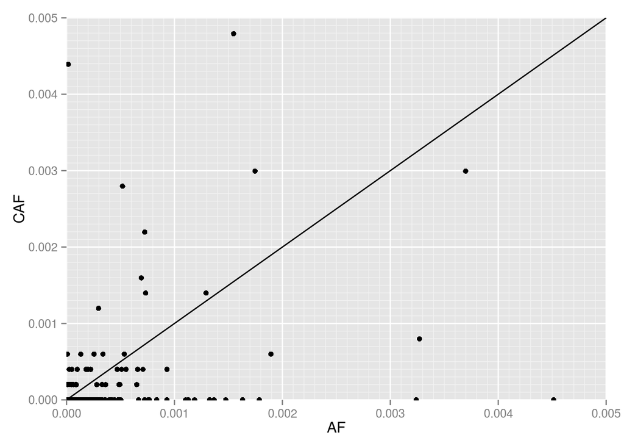

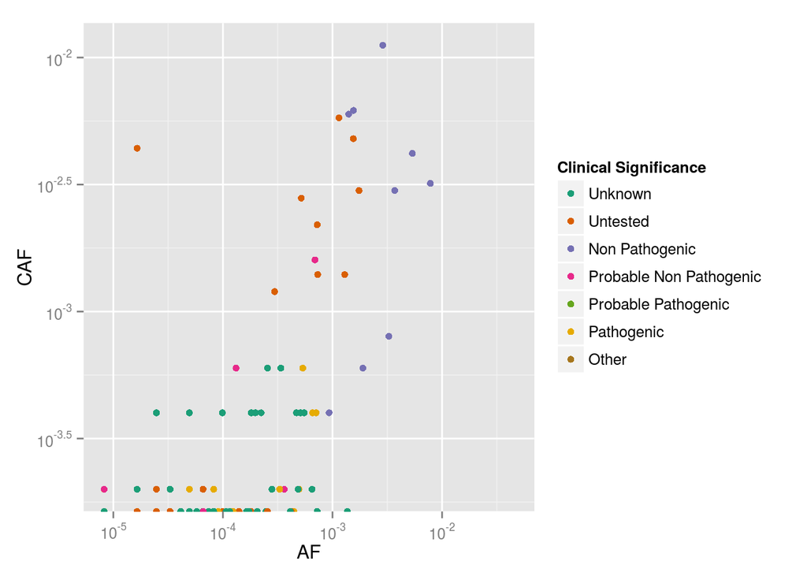

## Comportamiento de ExAC en la diferenciacion de los scores de Clinvar

Para los análisis siguientes utilizaremos sólo aquellas variantes con un score de CLNSIG asociado. De ahora en adelante cuando hablemos de frecuencia alelica (AF) nos estaremos refiriendo a la frecuencia alelica de ExAC.

```
##
##   0   1   2   3   4   5 255
##  65  77  10  10   4  54   2
```

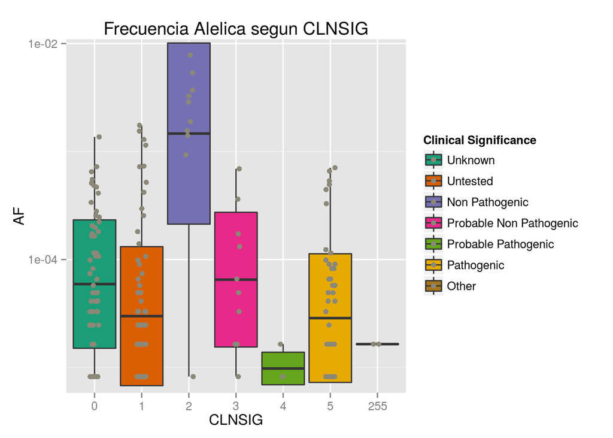

De los 14 genes, 13 tienen al menos una variante con valor de CLNSIG reportado

```
##         CLNSIG
## GENE      0  1  2  3  4  5 255
##   CBL    10  3  2  5  0  3   0
##   HRAS    1  0  0  1  0  0   0
##   KRAS    1  0  0  1  0  1   2
##   MAP2K1  1  0  0  0  0  0   0
##   MAP2K2  2  0  0  1  0  0   0
##   NF1    24 16  2  0  0  2   0
##   NRAS    0  1  0  0  0  1   0
##   PAH     1 55  0  0  3 32   0
##   PTPN11 12  1  1  0  1  9   0
##   RAF1    3  0  2  0  0  0   0
##   RHO     0  0  0  0  0  6   0
##   SOS1    9  1  3  1  0  0   0
##   SPRED1  1  0  0  1  0  0   0
```

Para analizar la correlación entre La frecuencia alélica y la patogenicidad, se considera como punto de corte un valor de AF de 10^(-4) como predictor (menor del cutoff se considera patogénico, y mayor como no patogénico), y se agrupan los valores de CLNSIG. Aquellas variantes con valores de 2 y 3 conforman el grupo no patogénico, mientras que aquelas con CLNSIG 4 y 5 serán el grupo patogénico. Las demas variantes serán descartadas.

```
##              CLNSIG
## AF            Path NonPath
##   PathPred      50       7
##   NonPathPred    8      13
```

```
## Call: xtabs(formula = ~AF + CLNSIG, data = aux_fisher)
## Number of cases in table: 78
## Number of factors: 2
## Test for independence of all factors:
##  Chisq = 19.821, df = 1, p-value = 8.506e-06
```

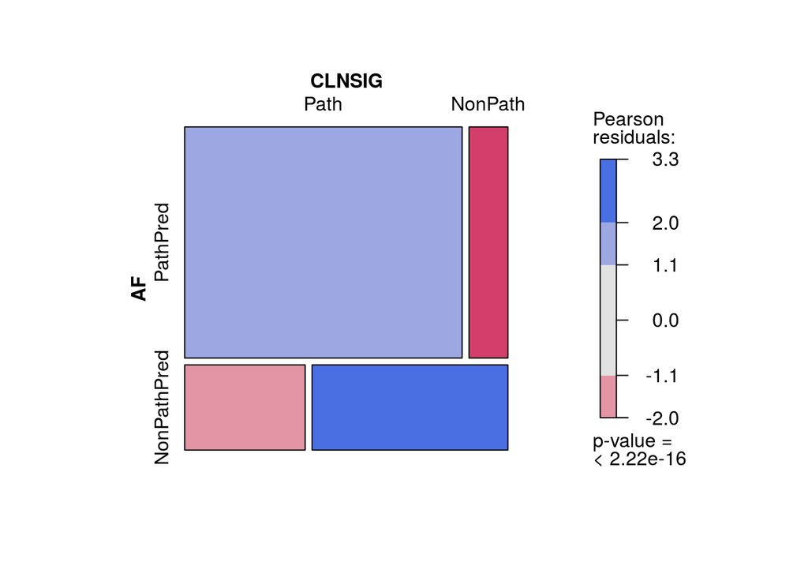

Si realizamos un test de Fisher sobre la tabla de contingencia generada

```
##
##  Fisher's Exact Test for Count Data
##
## data:  confusion_matrix
## p-value = 2.942e-05
## alternative hypothesis: true odds ratio is greater than 1
## 95 percent confidence interval:
##  3.662135      Inf
## sample estimates:
## odds ratio
##     11.099
```